# Course Project 1

# Imputing missing values

### The total number of missing values in the dataset

```r
sum(is.na(data[, 1]))
```

```
## [1] 2304
```

NAs have been replaced by the average value for each interval. A new dataset is created that is equal to the original dataset but with the missing data filled in.

```r
data2<-data
data2[, 1][is.na(data2[,1])]<-round(average_of_intervals[as.character(data2[, 3][is.na(data2[,1])])])
```

### A histogram of the total number of steps taken each day:

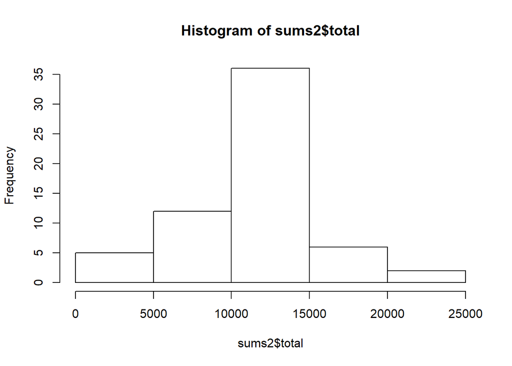

```r
sums2<-aggregate(data2[, 1], list(data2$date), sum)
names(sums2)<-c("day","total")
hist(sums2$total)
```

```r
mean2<-mean(sums2$total,na.rm = TRUE)
median2<-median(sums2$total,na.rm = TRUE)
```

# Differences in activity patterns between weekdays and weekends

### A new factor variable in the dataset is created with two levels - “weekday” and “weekend” indicating whether a given date is a weekday or weekend day.

```r
data2[,2]<-as.Date(data2[,2])

library(lubridate)
library(dplyr)
data2<-mutate(data2,weekday=wday(date))
data2$weekday[data2$weekday %in% c(7,1)]<-"weekend"
data2$weekday[data2$weekday %in% c(2,3,4,5,6)]<-"weekday"
data2$weekday<-factor(data2$weekday)
```

### A panel plot containing a time series plot of the 5-minute interval (x-axis) and the average number of steps taken, averaged across all weekday days or weekend days (y-axis).

```r
library(plyr)
```

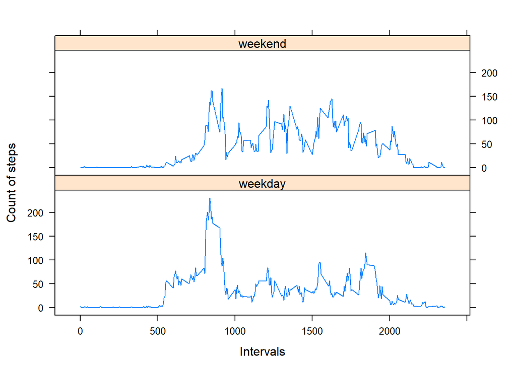

```r
data2$date<-NULL
weekday_factor<-ddply(data2,.(interval,weekday),summarize, mean = round(mean(steps), 2))
library(lattice)
xyplot(mean ~ interval | weekday, weekday_factor,
       type = "l", layout = c(1, 2), xlab = "Intervals", ylab = "Count of steps")
```